# 9_1_Residuals_Example

This notebook is a short demonstration of how to use the library *fable* to fit MEAN and NAIVE models:

```r
library(fpp3)
library(patchwork) # to easily locate graphs next to each other
```

```r
bricks <- aus_production %>%
  filter_index("1970 Q1" ~ "2004 Q4") %>% # Shorthand for filtering data between 1970 and 2004
  select(Bricks)
```

```r
bricks_fit <- bricks %>% model(
                                Mean = MEAN(Bricks), #Fit two models at once
                                Nv = NAIVE(Bricks)
                               )

bricks_fit
```

```
## # A mable: 1 x 2
##      Mean      Nv
##   <model> <model>
## 1  <MEAN> <NAIVE>
```

The dimensions of the resulting *mable* (model table) are 1 row (one time series) and 2 columns (2 models)

Now we extract the fitted values (and residuals) using `augment()`:

```r
model_vals <- bricks_fit %>% augment()
```

Let us plot the series and the fitted values:

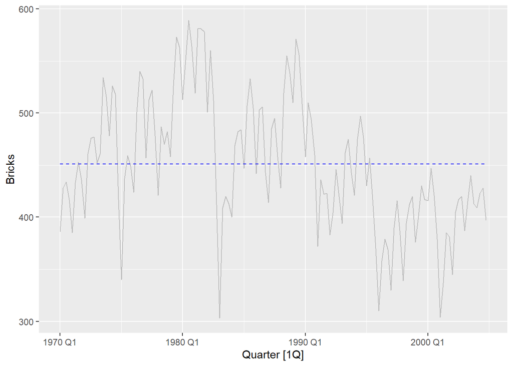

```r
model_vals %>%
  filter(.model == "Mean") %>%
  autoplot(Bricks, colour = "gray") +
  geom_line(aes(y=.fitted), colour = "blue", linetype = "dashed")
```

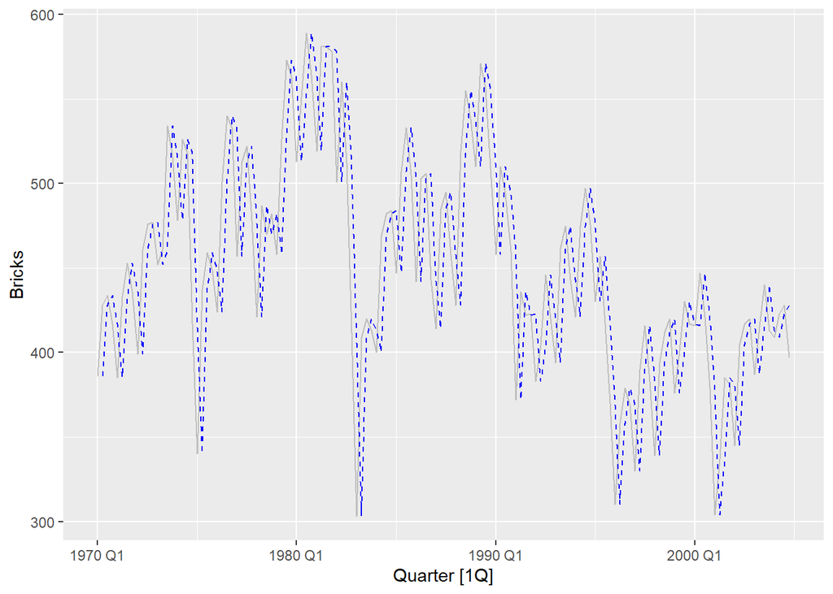

```r
model_vals %>%
  filter(.model == "Nv") %>%
  autoplot(Bricks, colour = "gray") +
  geom_line(aes(y=.fitted), colour = "blue", linetype = "dashed")
```

We would now like to generate a timeplot of the residuals:

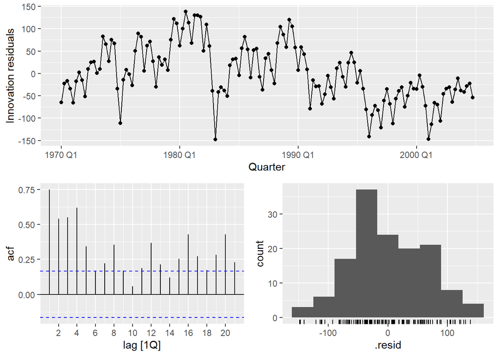

```r
bricks_fit %>%
  select(Mean) %>% # Selects the Mean model
  gg_tsresiduals()
```

```r
# Compute the mean of the residuals
model_vals %>% as_tibble() %>%
  filter(.model == "Mean") %>%
  summarise(mean = mean(.innov, na.rm = TRUE))
```

```
## # A tibble: 1 x 1
##        mean
##       <dbl>
## 1 -4.86e-15
```

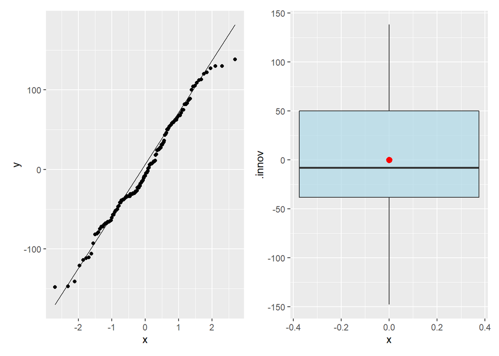

```r
mean_vals <- filter(model_vals, .model=="Mean")

# Generate qq_plot
p1 <- ggplot(mean_vals, aes(sample = .innov))
p1 <- p1 + stat_qq() + stat_qq_line()

# Generate box-plot
p2 <- ggplot(data = mean_vals, aes(y = .innov)) +
      geom_boxplot(fill="light blue", alpha = 0.7) +
      stat_summary(aes(x=0), fun="mean", colour= "red") # Include the mean

p1 + p2
```

1. The residuals are highly correlated, as the correlogram clearly shows (ACF values outside the dashed bounds)
- In this case this is clearly related to the simplicity of the model. The residuals look exactly like the time plot, only shifted by the mean of the time series.
- We are barely using information in the model. To fix this we would need to change the model.
2. The residuals have mean 0 (they are the series shifted by the mean of the series)
3. Visual inspection of the variance of the residuals across historical data indicates lack of homoskedasticity. There are recession periods (such as 1982 or 1974) where the variation of the series is much higher.
- NOTE: visual inspection is not a substitute for formal testing, but we will spare that for now.
4. Visual inspection agrees with the hypothesis that the residuals are fairly normal. The histogram seems relatively bell shaped and the distribution adjusts fairly well to the QQ-plot (except on the tails and perhaps a bit in the middle). The boxplot further confirms the relative symmetry of the distribution, showing as well that the mean is close to the median.
- To formally assess the normality we would need to perform a test, something we will not do for now.
- Understand that **the normality check is applied to the unordered set of residuals** (the frequency distribution of the residuals). We may have residuals that follow a normal distribution but that are arranged in a heteroskedastic manner.

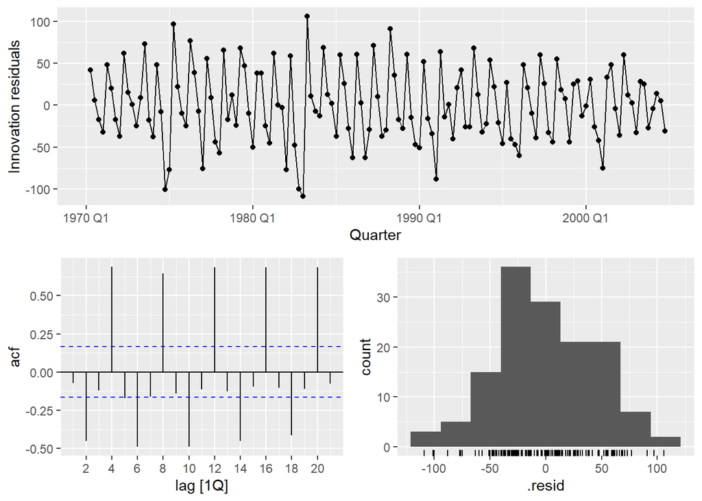

```r
bricks_fit %>%
  select(Nv) %>%
  gg_tsresiduals()
```

```r
# Compute the mean of the residuals
model_vals %>% as_tibble() %>%
  filter(.model == "Nv") %>%
  summarise(mean = mean(.innov, na.rm = TRUE))
```

```
## # A tibble: 1 x 1
##     mean
##    <dbl>
## 1 0.0791
```

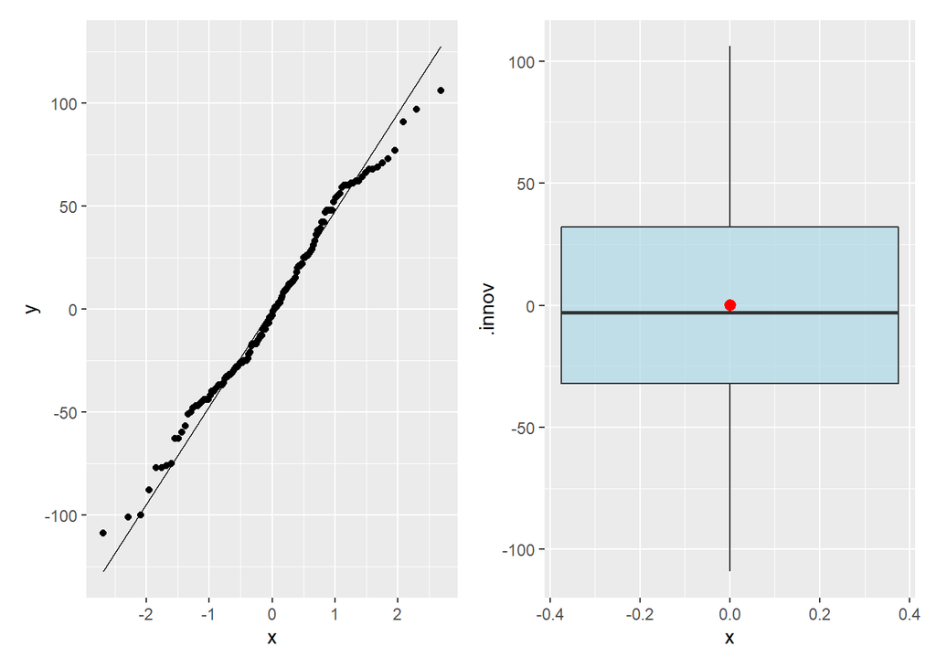

```r
mean_vals <- filter(model_vals, .model=="Nv")

# Generate qq_plot
p1 <- ggplot(mean_vals, aes(sample = .innov))
p1 <- p1 + stat_qq() + stat_qq_line()

# Generate box-plot
p2 <- ggplot(data = mean_vals, aes(y = .innov)) +
      geom_boxplot(fill="light blue", alpha = 0.7) +
      stat_summary(aes(x=0), fun="mean", colour= "red") # Include the mean

p1 + p2
```

1. The residuals are clearly correlated. First order differencing has not been sufficient to render the series white noise in this case.
2. The innovation residuals mean is close to 0 (0.08). To formally assess if this difference is statistically significant we could perform a t-test.
3. These residuals are more homoskedastic than those of the mean model. The variance of the residuals remains more uniform across the historical data. The crisis in 1974 and 1982-83 could be treated as outliers.
- NOTE: visual inspection is not a substitute for formal testing, but we will spare that for now.
4. Visually the residuals seem to be normally distributed. The histogram seems symmetric and relatively bell-shaped. The values adjust well in the qq-plot with the exception of the tails. The box-plox confirms the symmetry of the distribution and the closeness of mean and median.
- To formally assess the normality we would need to perform a test, something we will not do for now.
- Understand that **the normality check is applied to the unordered set of residuals** (the frequency distribution of the residuals). Hence the apparent contradiction between the heteroskedasticity check (performed on the time-ordered set of residuals) and the normality check.